# Mueller_ds202_lab4

# DS 202 - Lab #4

# Joining and Tidying ISU Football Data

# Madalyn Mueller & Sydney Thompson

```r
library(tidyverse)
```

```r
library(ggplot2)
library(dplyr)
library(readxl)
defense <- read_excel('/Users/maddiemueller/Desktop/cyclonesFootball2020.xlsx', sheet='Defensive')
str(defense)
```

```
## tibble [372 × 11] (S3: tbl_df/tbl/data.frame)
##  $ Name             : chr [1:372] "Rose, Mike" "Rose, Mike" "Rose, Mike" "Rose, Mike" ...
##  $ Opponent_Opponent: chr [1:372] "Louisiana" "TCU" "Oklahoma" "Texas Tech" ...
##  $ Tackles_Solo     : chr [1:372] "2" "6" "6" "3" ...
##  $ Tackles_ASST     : chr [1:372] "4" "4" "5" "0" ...
##  $ Tackles_TFL      : chr [1:372] "1.0" "0" "1.5" "1.0" ...
##  $ Tackles_Sack     : chr [1:372] "0" "0" "0.5" "0" ...
##  $ Turnover_FF      : chr [1:372] "0" "0" "0" "0" ...
##  $ Turnover_FR      : chr [1:372] "0" "0" "0" "0" ...
##  $ Turnover_INT     : chr [1:372] "0" "1" "0" "0" ...
##  $ Pass_QBH         : chr [1:372] "0" "0" "1" "0" ...
##  $ Pass_PB          : chr [1:372] "0" "0" "0" "0" ...
```

```r
offense <- read_excel('/Users/maddiemueller/Desktop/cyclonesFootball2020.xlsx', sheet='Offensive')
str(offense)
```

```
## tibble [156 × 12] (S3: tbl_df/tbl/data.frame)
##  $ Name             : chr [1:156] "Akers, Landen" "Akers, Landen" "Akers, Landen" "Akers, Landen" ...
##  $ Opponent_Opponent: chr [1:156] "Louisiana" "TCU" "Oklahoma" "Texas Tech" ...
##  $ Receiving_REC    : chr [1:156] "0" "2" "1" "4" ...
##  $ Receiving_YDS    : chr [1:156] "0" "60" "35" "34" ...
##  $ Receiving_TD     : chr [1:156] "0" "0" "0" "0" ...
##  $ Rushing_ATT      : chr [1:156] NA NA NA NA ...
##  $ Rushing_YDS      : chr [1:156] NA NA NA NA ...
##  $ Rushing_TD       : chr [1:156] NA NA NA NA ...
##  $ Passing_CMP-ATT  : chr [1:156] NA NA NA NA ...
##  $ Passing_YDS      : chr [1:156] NA NA NA NA ...
##  $ Passing_TD       : chr [1:156] NA NA NA NA ...
##  $ Passing_INT      : chr [1:156] NA NA NA NA ...
```

```r
bio <- read_excel('/Users/maddiemueller/Desktop/cyclonesFootball2020.xlsx', sheet='Biography')
str(bio)
```

```
## tibble [116 × 7] (S3: tbl_df/tbl/data.frame)
##  $ Name      : chr [1:116] "Akers, Landen" "Allen, Chase" "Anderson, Ezeriah" "Antoine Jr. , Michal" ...
##  $ Position  : chr [1:116] "Wide Receiver" "Tight End" "Wide Receiver" "Defensive Back" ...
##  $ Height    : chr [1:116] "6-0" "6-7" "6-5" "6-0" ...
##  $ Weight    : chr [1:116] "191" "240" "208" "180" ...
##  $ Class     : chr [1:116] "Redshirt Senior" "Redshirt Senior" "Redshirt Freshman" "Freshman" ...
##  $ Hometown  : chr [1:116] "Cedar Rapids, Iowa" "Nixa, Mo." "Seffner, Fla." "Ft. Lauderdale, Fla." ...
##  $ Highschool: chr [1:116] "Washington" "Nixa" "Armwood" "Cardinal Gibbons" ...
```

# Part 1: Cleaning data

# Although the three Excel sheets are loaded into R, they are not useful before some cleaning. Manipulate the three imported data frames, so that in the cleaned dataset:

## 1. The player names and opponent names are factors.

```r
str(defense)
```

```
## tibble [372 × 11] (S3: tbl_df/tbl/data.frame)
##  $ Name             : chr [1:372] "Rose, Mike" "Rose, Mike" "Rose, Mike" "Rose, Mike" ...
##  $ Opponent_Opponent: chr [1:372] "Louisiana" "TCU" "Oklahoma" "Texas Tech" ...
##  $ Tackles_Solo     : chr [1:372] "2" "6" "6" "3" ...
##  $ Tackles_ASST     : chr [1:372] "4" "4" "5" "0" ...
##  $ Tackles_TFL      : chr [1:372] "1.0" "0" "1.5" "1.0" ...
##  $ Tackles_Sack     : chr [1:372] "0" "0" "0.5" "0" ...
##  $ Turnover_FF      : chr [1:372] "0" "0" "0" "0" ...
##  $ Turnover_FR      : chr [1:372] "0" "0" "0" "0" ...
##  $ Turnover_INT     : chr [1:372] "0" "1" "0" "0" ...
##  $ Pass_QBH         : chr [1:372] "0" "0" "1" "0" ...
##  $ Pass_PB          : chr [1:372] "0" "0" "0" "0" ...
```

```r
as.factor(defense$Name)
```

```
##   [1] Rose, Mike         Rose, Mike         Rose, Mike
##   [4] Rose, Mike         Rose, Mike         Rose, Mike
##   [7] Rose, Mike         Rose, Mike         Rose, Mike
##  [10] Rose, Mike         Rose, Mike         Rose, Mike
##  [13] Hummel, Jake       Hummel, Jake       Hummel, Jake
##  [16] Hummel, Jake       Hummel, Jake       Hummel, Jake
##  [19] Hummel, Jake       Hummel, Jake       Hummel, Jake
##  [22] Hummel, Jake       Hummel, Jake       Hummel, Jake
##  [25] Vance, O'Rien      Vance, O'Rien      Vance, O'Rien
##  [28] Vance, O'Rien      Vance, O'Rien      Vance, O'Rien
##  [31] Vance, O'Rien      Vance, O'Rien      Vance, O'Rien
##  [34] Vance, O'Rien      Vance, O'Rien      Vance, O'Rien
##  [37] Young, Isheem      Young, Isheem      Young, Isheem
##  [40] Young, Isheem      Young, Isheem      Young, Isheem
##  [43] Young, Isheem      Young, Isheem      Young, Isheem
```

[output cut: 110 more lines]

```r
as.factor(defense$Opponent_Opponent)
```

```
##   [1] Louisiana     TCU           Oklahoma      Texas Tech    Oklahoma St.
##   [6] Kansas        Baylor        Kansas State  Texas         West Virginia
##  [11] Oklahoma      Oregon        Louisiana     TCU           Oklahoma
##  [16] Texas Tech    Oklahoma St.  Kansas        Baylor        Kansas State
##  [21] Texas         West Virginia Oklahoma      Oregon        Louisiana
##  [26] TCU           Oklahoma      Texas Tech    Oklahoma St.  Kansas
##  [31] Baylor        Kansas State  Texas         West Virginia Oklahoma
##  [36] Oregon        Louisiana     TCU           Oklahoma      Texas Tech
##  [41] Oklahoma St.  Kansas        Baylor        Kansas State  Texas
##  [46] West Virginia Oklahoma      Oregon        Louisiana     TCU
##  [51] Oklahoma      Texas Tech    Oklahoma St.  Kansas        Baylor
##  [56] Kansas State  Texas         West Virginia Oklahoma      Oregon
##  [61] Louisiana     TCU           Oklahoma      Texas Tech    Oklahoma St.
##  [66] Kansas        Baylor        West Virginia Oklahoma      Louisiana
##  [71] TCU           Oklahoma      Texas Tech    Oklahoma St.  Kansas
```

[output cut: 61 more lines]

```r
str(offense)
```

```
## tibble [156 × 12] (S3: tbl_df/tbl/data.frame)
##  $ Name             : chr [1:156] "Akers, Landen" "Akers, Landen" "Akers, Landen" "Akers, Landen" ...
##  $ Opponent_Opponent: chr [1:156] "Louisiana" "TCU" "Oklahoma" "Texas Tech" ...
##  $ Receiving_REC    : chr [1:156] "0" "2" "1" "4" ...
##  $ Receiving_YDS    : chr [1:156] "0" "60" "35" "34" ...
##  $ Receiving_TD     : chr [1:156] "0" "0" "0" "0" ...
##  $ Rushing_ATT      : chr [1:156] NA NA NA NA ...
##  $ Rushing_YDS      : chr [1:156] NA NA NA NA ...
##  $ Rushing_TD       : chr [1:156] NA NA NA NA ...
##  $ Passing_CMP-ATT  : chr [1:156] NA NA NA NA ...
##  $ Passing_YDS      : chr [1:156] NA NA NA NA ...
##  $ Passing_TD       : chr [1:156] NA NA NA NA ...
##  $ Passing_INT      : chr [1:156] NA NA NA NA ...
```

```r
as.factor(offense$Name)
```

```
##   [1] Akers, Landen      Akers, Landen      Akers, Landen
##   [4] Akers, Landen      Akers, Landen      Akers, Landen
##   [7] Akers, Landen      Akers, Landen      Akers, Landen
##  [10] Akers, Landen      Akers, Landen      Akers, Landen
##  [13] Brock, Jirehl      Brock, Jirehl      Brock, Jirehl
##  [16] Brock, Jirehl      Brock, Jirehl      Brock, Jirehl
##  [19] Brock, Jirehl      Brock, Jirehl      Brock, Jirehl
##  [22] Brock, Jirehl      Hutchinson, Xavier Hutchinson, Xavier
##  [25] Hutchinson, Xavier Hutchinson, Xavier Hutchinson, Xavier
##  [28] Hutchinson, Xavier Hutchinson, Xavier Hutchinson, Xavier
##  [31] Hutchinson, Xavier Hutchinson, Xavier Hutchinson, Xavier
##  [34] Hutchinson, Xavier Nwangwu, Kene      Nwangwu, Kene
##  [37] Nwangwu, Kene      Nwangwu, Kene      Nwangwu, Kene
##  [40] Nwangwu, Kene      Nwangwu, Kene      Nwangwu, Kene
##  [43] Nwangwu, Kene      Nwangwu, Kene      Nwangwu, Kene
```

[output cut: 38 more lines]

```r
as.factor(offense$Opponent_Opponent)
```

```
##   [1] Louisiana     TCU           Oklahoma      Texas Tech    Oklahoma St.
##   [6] Kansas        Baylor        Kansas State  Texas         West Virginia
##  [11] Oklahoma      Oregon        Oklahoma      Texas Tech    Oklahoma St.
##  [16] Kansas        Baylor        Kansas State  Texas         West Virginia
##  [21] Oklahoma      Oregon        Louisiana     TCU           Oklahoma
##  [26] Texas Tech    Oklahoma St.  Kansas        Baylor        Kansas State
##  [31] Texas         West Virginia Oklahoma      Oregon        Louisiana
##  [36] TCU           Oklahoma      Texas Tech    Oklahoma St.  Kansas
##  [41] Baylor        Kansas State  Texas         West Virginia Oklahoma
##  [46] Oregon        Louisiana     TCU           Oklahoma      Texas Tech
##  [51] Oklahoma St.  Kansas        Baylor        Kansas State  Texas
##  [56] West Virginia Oklahoma      Oregon        Louisiana     TCU
##  [61] Oklahoma      Texas Tech    Oklahoma St.  Kansas        Baylor
##  [66] Kansas State  Texas         Oklahoma      Oregon        Louisiana
##  [71] TCU           Oklahoma      Texas Tech    Oklahoma St.  Kansas
```

[output cut: 18 more lines]

```r
str(bio)
```

```
## tibble [116 × 7] (S3: tbl_df/tbl/data.frame)
##  $ Name      : chr [1:116] "Akers, Landen" "Allen, Chase" "Anderson, Ezeriah" "Antoine Jr. , Michal" ...
##  $ Position  : chr [1:116] "Wide Receiver" "Tight End" "Wide Receiver" "Defensive Back" ...
##  $ Height    : chr [1:116] "6-0" "6-7" "6-5" "6-0" ...
##  $ Weight    : chr [1:116] "191" "240" "208" "180" ...
##  $ Class     : chr [1:116] "Redshirt Senior" "Redshirt Senior" "Redshirt Freshman" "Freshman" ...
##  $ Hometown  : chr [1:116] "Cedar Rapids, Iowa" "Nixa, Mo." "Seffner, Fla." "Ft. Lauderdale, Fla." ...
##  $ Highschool: chr [1:116] "Washington" "Nixa" "Armwood" "Cardinal Gibbons" ...
```

```r
as.factor(bio$Name)
```

```
##   [1] Akers, Landen          Allen, Chase           Anderson, Ezeriah
##   [4] Antoine Jr. , Michal   Assalley, Connor       Azunna, Arnold
##   [7] Bailey, Cordarrius     Bailey, JaQuan         Bailey, Joshua
##  [10] Bitter, Aidan          Bouman, Aidan          Brock, Jirehl
##  [13] Cassady, Mason         Chambers, Mason        Clark, Blake
##  [16] Coberley, Beau         Davis, Dae'Shawn       Dean, Easton
##  [19] Dekkers, Hunter        Downing, Trevor        Doxzon, Blaze
##  [22] Dunkleberger, Benjamin Dunn, Corey            Edwards II, Virdel
##  [25] Eisworth II, Greg      Foster, Sean           Gaye, Answer
##  [28] Gibson, Hayes          Greiner, Derek         Greiner, Seth
##  [31] Guess, Connor          Hall, Breece           Hanika, DeShawn
##  [34] Hathcock, Koby         Hester, Jack           Hillmann, Jacob
##  [37] Horne, Aric            Hudson, Robert         Hufford, Jarrod
##  [40] Hummel, Jake           Hummel, Levi           Hutchinson, Xavier
##  [43] Jackson, Daniel        Jackson, Kendell       James, D'Shayne
```

[output cut: 25 more lines]

## 2. All offensive and defensive statistics are numerical. The Weight column in biography is also numeric. (Optional: Read ?across and learn to mutate multiple columns simultaneously using the across function in dplyr)

```r
defense <- defense %>%
  mutate(Tackles_Solo = as.numeric(Tackles_Solo)) %>% na.omit
defense <- defense %>%
  mutate(Tackles_ASST = as.numeric(Tackles_ASST)) %>% na.omit
defense <- defense %>%
  mutate(Tackles_TFL = as.numeric(Tackles_TFL)) %>% na.omit
defense <- defense %>%
  mutate(Tackles_Sack = as.numeric(Tackles_Sack)) %>% na.omit
defense <- defense %>%
  mutate(Turnover_FF = as.numeric(Turnover_FF)) %>% na.omit
defense <- defense %>%
  mutate(Turnover_FR = as.numeric(Turnover_FR)) %>% na.omit
defense <- defense %>%
  mutate(Turnover_INT = as.numeric(Turnover_INT)) %>% na.omit
defense <- defense %>%
  mutate(Pass_QBH = as.numeric(Pass_QBH)) %>% na.omit
defense <- defense %>%
  mutate(Pass_PB = as.numeric(Pass_PB)) %>% na.omit
```

```r
offense <- offense %>%
  mutate(Receiving_REC = as.numeric(Receiving_REC))
offense <- offense %>%
  mutate(Receiving_YDS = as.numeric(Receiving_YDS))
offense <- offense %>%
  mutate(Receiving_TD = as.numeric(Receiving_TD))
offense <- offense %>%
  mutate(Rushing_ATT = as.numeric(Rushing_YDS))
offense <- offense %>%
  mutate(Rushing_YDS = as.numeric(Rushing_YDS))
offense <- offense %>%
  mutate(Rushing_TD = as.numeric(Rushing_TD))
offense <- offense %>%
  mutate('Passing_CMP-ATT' = as.numeric('Passing_CMP-ATT'))
offense <- offense %>%
  mutate(Passing_YDS = as.numeric(Passing_YDS))
offense <- offense %>%
  mutate(Passing_TD = as.numeric(Passing_TD))
offense <- offense %>%
  mutate(Passing_INT = as.numeric(Passing_INT))
```

```r
bio <- bio %>%
  mutate(Weight = as.numeric(Weight))
```

## 3. Change the Height column in biography into numeric. (Hint: Use a unit that works well)

```r
bio <- bio %>%
  mutate(Height = as.numeric(Height))
```

# By cleaning the three data frames in R, at the end of this step you should have the following three clean data frames: defClean, offClean, and bioClean. Print the structures of these data frames using str().

# Part 2: Tidying

# For the following questions, work on the cleaned data frames defClean, offClean, and bioClean.

## 1. Reformat the offClean data frame into a tidy format using pivot_longer. The type of statistic (Receiving_REC for the number of receivings, Receiving_YDS for receiving yards, etc) is added as a new key column named stat.

```r
offtidy <- offense %>%
  pivot_longer(Receiving_REC:Passing_INT, names_to='stat', values_to='count')
head(offtidy)
```

```
## # A tibble: 6 x 4
##   Name          Opponent_Opponent stat          count
##   <chr>         <chr>             <chr>         <dbl>
## 1 Akers, Landen Louisiana         Receiving_REC     0
## 2 Akers, Landen Louisiana         Receiving_YDS     0
## 3 Akers, Landen Louisiana         Receiving_TD      0
## 4 Akers, Landen Louisiana         Rushing_ATT      NA
## 5 Akers, Landen Louisiana         Rushing_YDS      NA
## 6 Akers, Landen Louisiana         Rushing_TD       NA
```

## 2. Show on the distributions of the offensive statistics. The distribution of each offensive statsitic should be shown in a separate facet. Explain the patterns you see.

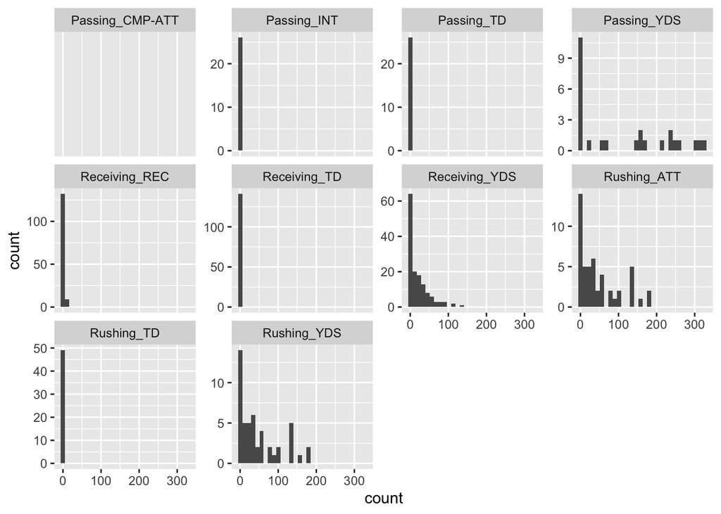

```r
ggplot(offtidy, aes(x=count)) + geom_histogram() + facet_wrap(~stat, scales='free_y')
```

## 3. Did ISU have better offense against Oregon or Oklahoma? Answer this question by creating a scatterplot with the x- and y-axes being the receiving yards of the ISU players against these two opponents. A large number of receiving yards indicates good offense.

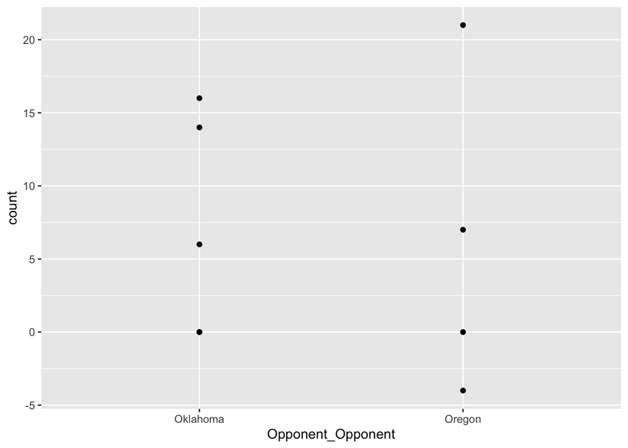

```r
offtidyorok <- offtidy %>%
  filter(stat == 'Receiving_YDS')
orok <- offtidyorok %>%
  filter(Opponent_Opponent == c('Oregon','Oklahoma'))
ggplot(orok, aes(x=Opponent_Opponent, y=count)) + geom_point()
```

# Now turn our attention to the player biography.

## 4. Separate the Hometown column into two columns, namely, the city and the state where the player comes from. Print the first few rows of these two columns. (Hint: look at the sep= argument of separate)

```r
tidybio <- bio %>%
  separate(Hometown, into = c("City", "State"))
head(tidybio)
```

```
## # A tibble: 6 x 8
##   Name         Position    Height Weight Class      City    State   Highschool
##   <chr>        <chr>        <dbl>  <dbl> <chr>      <chr>   <chr>   <chr>
## 1 Akers, Land… Wide Recei…     NA    191 Redshirt … Cedar   Rapids  Washington
## 2 Allen, Chase Tight End       NA    240 Redshirt … Nixa    Mo      Nixa
## 3 Anderson, E… Wide Recei…     NA    208 Redshirt … Seffner Fla     Armwood
## 4 Antoine Jr.… Defensive …     NA    180 Freshman   Ft      Lauder… Cardinal Gi…
## 5 Assalley, C… Placekicker     NA    195 Redshirt … Naperv… Ill     Central
## 6 Azunna, Arn… Defensive …     NA    199 Redshirt … Grand   Prairie Lake Ridge
```

## 5. How many players are there from each state?

```r
tidybio %>%
  group_by(State) %>% count(State)
```

```
## # A tibble: 39 x 2
## # Groups:   State [39]
##    State         n
##    <chr>     <int>
##  1 Ariz          4
##  2 Australia     1
##  3 Beach         1
##  4 Bluffs        1
##  5 Calif         1
##  6 Center        1
##  7 City          3
##  8 Des           3
##  9 Fallon        1
## 10 Falls         1
## # … with 29 more rows
```

# Part 3: Joining Data Frames

## 1. Find which states do the ISU players (both defensive and offensive) come from. Create an appropriate numerical or graphical summary.

```r
defbio <- inner_join(defense, tidybio, by = 'Name')
offbio <- inner_join(offense, tidybio, by = 'Name')
```

```r
defbio %>%
  group_by(State) %>% count(State)
```

```
## # A tibble: 20 x 2
## # Groups:   State [20]
##    State          n
##    <chr>      <int>
##  1 Ariz          24
##  2 Beach         11
##  3 Bluffs         7
##  4 City           7
##  5 Fla           47
##  6 Ga            24
##  7 Grove         23
##  8 Ill           20
##  9 Iowa          32
## 10 Mich          12
## 11 Minn           7
## 12 Moines        26
## 13 Ohio          35
## 14 Pa            12
## 15 Petersburg     9
## 16 Port           8
## 17 Prairie        9
## 18 Rapids        24
## 19 S              6
## 20 Texas         18
```

```r
offbio %>%
  group_by(State) %>% count(State)
```

```
## # A tibble: 11 x 2
## # Groups:   State [11]
##    State      n
##    <chr>  <int>
##  1 Ariz      12
##  2 Fla       23
##  3 Grove     11
##  4 Ill       10
##  5 Iowa       3
##  6 Kan       24
##  7 Mo        11
##  8 Ohio      11
##  9 Okla      23
## 10 Rapids    12
## 11 Texas     16
```

## 2. How does the performance of quarterback Brock Purdy relate to the performance of the ISU team?

```r
defoff <- inner_join(defense, offense, by = "Name")
brock <- defoff %>%
  filter(Name == 'Purdy, Brock')
mean(brock$Passing_YDS)
```

```
## [1] 229.1667
```

```r
mean(defoff$Passing_YDS, na.rm=TRUE)
```

```
## [1] 125.6906
```

## 3. Which ISU player(s) made the biggest progress over the last year? Compare the player-level statistics (i.e. averages and totals for each player) using both the 2020 and the 2019 data here. Choose for yourself the player statistics to investigate.

```r
defense %>%
  group_by(Name) %>% count(Tackles_Solo)
```

```
## # A tibble: 109 x 3
## # Groups:   Name [37]
##    Name           Tackles_Solo     n
##    <chr>                 <dbl> <int>
##  1 Akers, Landen             0     9
##  2 Akers, Landen             1     3
##  3 Azunna, Arnold            0     1
##  4 Azunna, Arnold            1     5
##  5 Azunna, Arnold            2     1
##  6 Azunna, Arnold            4     2
##  7 Bailey, JaQuan            0     3
##  8 Bailey, JaQuan            1     2
##  9 Bailey, JaQuan            2     4
## 10 Bailey, JaQuan            3     2
## # … with 99 more rows
```

```r
offense %>%
  group_by(Name) %>% count(Passing_YDS)
```

```
## # A tibble: 30 x 3
## # Groups:   Name [16]
##    Name               Passing_YDS     n
##    <chr>                    <dbl> <int>
##  1 Akers, Landen               NA    12
##  2 Allen, Chase                NA    11
##  3 Bitter, Aidan               NA     5
##  4 Brock, Jirehl               NA    10
##  5 Dean, Easton                NA    12
##  6 Dekkers, Hunter              0     1
##  7 Dekkers, Hunter             55     1
##  8 Dekkers, Hunter             63     1
##  9 Hall, Breece                NA    12
## 10 Hutchinson, Xavier          NA    12
## # … with 20 more rows
```

```r
defense2019 <- read_excel('/Users/maddiemueller/Desktop/cyclonesFootball2019.xlsx', sheet='Defensive')
str(defense2019)
```

```
## tibble [502 × 11] (S3: tbl_df/tbl/data.frame)
##  $ Name             : chr [1:502] "White, Lawrence" "White, Lawrence" "White, Lawrence" "White, Lawrence" ...
##  $ Opponent_Opponent: chr [1:502] "UNI" "Iowa" "ULM" "Baylor" ...
##  $ Tackles_Solo     : chr [1:502] "4" "4" "3" "4" ...
##  $ Tackles_ASST     : chr [1:502] "4" "7" "5" "2" ...
##  $ Tackles_TFL      : chr [1:502] "0" "0" "0" "0" ...
##  $ Tackles_Sack     : chr [1:502] "0" "0" "0" "0" ...
##  $ Turnover_FF      : chr [1:502] "0" "0" "0" "0" ...
##  $ Turnover_FR      : chr [1:502] "0" "0" "0" "0" ...
##  $ Turnover_INT     : chr [1:502] "0" "0" "1" "0" ...
##  $ Pass_QBH         : chr [1:502] "1" "0" "0" "0" ...
##  $ Pass_PB          : chr [1:502] "1" "2" "0" "0" ...
```

```r
offense2019 <- read_excel('/Users/maddiemueller/Desktop/cyclonesFootball2019.xlsx', sheet='Offensive')
str(offense2019)
```

```
## tibble [195 × 12] (S3: tbl_df/tbl/data.frame)
##  $ Name             : chr [1:195] "Akers, Landen" "Akers, Landen" "Akers, Landen" "Akers, Landen" ...
##  $ Opponent_Opponent: chr [1:195] "UNI" "Iowa" "ULM" "Baylor" ...
##  $ Rushing_ATT      : chr [1:195] "0" "0" "1" "0" ...
##  $ Rushing_YDS      : chr [1:195] "0" "0" "8" "0" ...
##  $ Rushing_TD       : chr [1:195] "0" "0" "0" "0" ...
##  $ Receiving_REC    : chr [1:195] "1" "0" "0" "0" ...
##  $ Receiving_YDS    : chr [1:195] "21" "0" "0" "0" ...
##  $ Receiving_TD     : chr [1:195] "0" "0" "0" "0" ...
##  $ Passing_CMP-ATT  : chr [1:195] NA NA NA NA ...
##  $ Passing_YDS      : chr [1:195] NA NA NA NA ...
##  $ Passing_TD       : chr [1:195] NA NA NA NA ...
##  $ Passing_INT      : chr [1:195] NA NA NA NA ...
```

```r
defense2019 %>%
  group_by(Name) %>% count(Tackles_Solo)
```

```
## # A tibble: 135 x 3
## # Groups:   Name [43]
##    Name           Tackles_Solo     n
##    <chr>          <chr>        <int>
##  1 Akers, Landen  0                5
##  2 Akers, Landen  1                7
##  3 Akers, Landen  2                1
##  4 Allen, Chase   0               11
##  5 Allen, Chase   1                2
##  6 Azunna, Arnold 0                1
##  7 Azunna, Arnold 1                3
##  8 Azunna, Arnold 2                6
##  9 Azunna, Arnold 3                1
## 10 Bailey, JaQuan 0                2
## # … with 125 more rows
```

```r
offense2019 %>%
  group_by(Name) %>% count(Passing_YDS)
```

```
## # A tibble: 32 x 3
## # Groups:   Name [17]
##    Name                Passing_YDS     n
##    <chr>               <chr>       <int>
##  1 Akers, Landen       <NA>           13
##  2 Allen, Chase        <NA>           13
##  3 Brock, Jirehl       <NA>            4
##  4 Croney Jr., Sheldon <NA>           12
##  5 Hall, Breece        <NA>           12
##  6 Jones, Deshaunte    0              12
##  7 Jones, Deshaunte    51              1
##  8 Kolar, Charlie      <NA>           13
##  9 Lang, Johnnie       <NA>           12
## 10 Milton, Tarique     <NA>           13
## # … with 22 more rows
```

The most improved defensive player based on solo tackles was Jake Hummel. In 2019, he made 10 solo tackles, and in 2020 he made 28 solo tackles. The most improved offensive player based on passing yards was Dylan Soehner. In 2019 he made 0/NA passing yards and in 2020 he made 28 passing yards.